第二部分，聚类算法以及一些零散的算法

# Part 2

#### Principal Component Analysis(PCA，这里顺带讲下矩阵奇异值分解SVD)

主成分分析，是一种降维方法，你都能猜出来，降维是为了降低学习难度，提高模型泛化能力。这里有必要说一下降维和特征选择的区别(只是个人理解，不知对否)，降维是只关注于自变量这部分数据(也就是常说的X)，特征选择更多看重自变量对目标值（常说的y）的贡献或者说是影响。比如主成分分析的思想就是找到，自变量中所含信息较多的那部分变量（维度），而信息含量较多差不多就可以理解成，这个变量的数据变化较多（你也可以用信息熵的角度看），不是一成不变，比如你收集了很多人的体重关于身高，年龄的数据，结果发现你的所有年龄数据中，你收集的都是18岁的小朋友，那基本这个变量可以抛弃，没什么用。然后特征选择是啥呢，为了避免刚刚的错误，你重新收集了一部分样本，不是全18岁了，而是从1岁到80岁，各一个样本，均匀分布，很好，经过主成分分析处理，年龄这个变量是能够保留下来的，可是，同样这个变量数据没有卵用，因为体重是有规律随年龄变化的，可是你给我的数据却是，体重和年龄他俩的变化根本不合拍，体重满足一个分布变化，而年龄却是线性变化，应该能理解了吧。然后继续PCA： 首先注意下，做主成分分析之前一定要先把数据全部归一化，保证各个变量的变化都是平等的，比如身高一般是0.1m的变化，而体重是1千克1千克的变化，显然他们之间的变化幅度不平等。归一化很容易: $$x_{normolize}=\frac{x_{old}-\mu}{\frac{1}{n}\sum_i^n{(x_i - \mu)}}$$ 歇会儿再写。。。

#### Factor Analysis(FA)

#### 独立主成分分析

#### Reinforcement Learning

#### Hidden Markov Models

上边这四个部分，还没来得及写，抽空继续完善

### 聚类分析

这里先说一个概念，监督学习和非监督学习。很好理解，监督学习就是训练样本中已经告诉你了真实的输出是神马，就像我要将身高对性别建模，样本中身高和性别信息都有了，就是监督学习，从字面意思理解，就是我啥都告诉你了，你就按我告诉你的学，监督嘛。而如果样本中只有变量的信息，没有给你真实输出信息，那就是非监督学习，没有给你完整的信息，那就需要你自己去发现规律，比较灵活，你从性别信息了发现了中国性别比例不均衡，也是发现规律了。非监督学习中很重要的一块就是聚类，聚类就是单从样本的分布出发看看样本是不是明显聚集成几个类别。比如你调查了很多人的身高，男女老少的都有。然后你把身高信息统计出来。随便画个图感受一下：

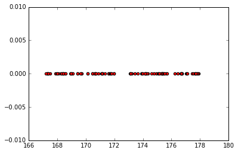

```python
import numpy as np
import matplotlib.pyplot as plt
%matplotlib inline
height_boy = 173 + 5 * np.random.random(50)
y = [0] * 50
height_girl = 167 + 5 * np.random.random(50)
plt.scatter(height_boy,y,c='r')
plt.scatter(height_girl,y,c='r')
plt.show()
```

就是把每个样本的身高描点，然后我们很容易就发现，这批样本根据他们的身高信息可以分为两类，一类身高要稍微矮一点，另一类身高稍高点。至于这两类我们该如何命名，到底反映了什么，那就是你的事了，规律是发现了，只不过这里这两类正好就是boy和girl，在我们生活中有确切的含义。  
聚类呢，有两种常见的算法

#### K-means

#### 层次聚类